# Node labels on trees

Jai Jot Kaur

11/3/2022

## The data set

Data that comes with an R package. Working with the `TDbook` package.

Load the packages and the data package `TDbook`:

```r
library(TDbook)
library(ggtree)
library(tidytree)
```

Load the data from teh data package, using the `data()` function. The data that we ae loading is - tree_boots - df_tip_data - df_inode_data

```r
data("tree_boots", "df_inode_data", "df_tip_data")
tree_boots
```

```
##
## Phylogenetic tree with 7 tips and 6 internal nodes.
##
## Tip labels:
##   Rangifer_tarandus, Cervus_elaphus, Bos_taurus, Ovis_orientalis, Suricata_suricatta, Cystophora_cristata, ...
## Node labels:
##   Mammalia, Artiodactyla, Cervidae, Bovidae, Carnivora, Caniformia
##
## Rooted; includes branch lengths.
```

Exercise 1. What is the class of this three objects

```r
class(tree_boots)
```

```
## [1] "phylo"
```

```r
class(df_inode_data)
```

```
## [1] "data.frame"
```

```r
class(df_tip_data)
```

```
## [1] "data.frame"
```

```r
typeof(tree_boots)
```

```
## [1] "list"
```

```r
typeof(df_inode_data)
```

```
## [1] "list"
```

```r
typeof(df_tip_data)
```

```
## [1] "list"
```

The class of `tree_boots` is phylogeny. The class of `df_inode_data` is data frame. The class of `df_tip_data` is data frame.

2. How many elements does `tree_boots` has

```r
str(tree_boots)
```

```
## List of 5
##  $ edge       : int [1:12, 1:2] 8 9 10 10 9 11 11 8 12 12 ...
##  $ edge.length: num [1:12] 1 1 1 1 1 1 1 1 2 1 ...
##  $ Nnode      : int 6
##  $ node.label : chr [1:6] "Mammalia" "Artiodactyla" "Cervidae" "Bovidae" ...
##  $ tip.label  : chr [1:7] "Rangifer_tarandus" "Cervus_elaphus" "Bos_taurus" "Ovis_orientalis" ...
##  - attr(*, "class")= chr "phylo"
##  - attr(*, "order")= chr "cladewise"
```

3. How many rows does `df_tip_data` and `df_inode_data` have.

```r
nrow(df_tip_data)
```

```
## [1] 7
```

```r
nrow(df_inode_data)
```

```
## [1] 6
```

The number of rows in `df_tip_data` is 7. The number of rows in `df_inode_data` is 6.

4. Compare the row numbers of both objects to the lengths of the `$tip.label` and `$node.label` elements of `tree_boots`

```r
length(tree_boots$tip.label)
```

```
## [1] 7
```

```r
length(tree_boots$node.label)
```

```
## [1] 6
```

```r
tree_boots$tip.label %>% length()
```

```
## [1] 7
```

```r
tree_boots$node.label %>% length()
```

```
## [1] 6
```

The length of the `$tip.label` element of `tree_boots` is 7. This is the same as the number of rows in `df_tip_data`. This means that there is a relationship between these two. Each tip label has data The length of the `$node.label` element of `tree_boots` is 6. This is the same as the number of rows in `df_inode_data`.

5. Join the tree object with the data table that contains tip data and create an object called `tree_joined`.

```r
library(tidytree) # not the one from dplyr package
colnames(df_tip_data)
```

```
##  [1] "Newick_label"   "vernacularName" "imageURL"       "imageLicense"
##  [5] "imageAuthor"    "infoURL"        "mass_in_kg"     "trophic_habit"
##  [9] "ncbi_taxid"     "rank"
```

```r
df_tip_data$Newick_label
```

```
## [1] "Rangifer_tarandus"   "Cervus_elaphus"      "Bos_taurus"
## [4] "Ovis_orientalis"     "Suricata_suricatta"  "Cystophora_cristata"
## [7] "Mephitis_mephitis"
```

```r
tree_boots$tip.label
```

```
## [1] "Rangifer_tarandus"   "Cervus_elaphus"      "Bos_taurus"
## [4] "Ovis_orientalis"     "Suricata_suricatta"  "Cystophora_cristata"
## [7] "Mephitis_mephitis"
```

```r
# rename the 'Newick_label" column as "label"
df_mutated <- mutate(df_tip_data, label = Newick_label)
colnames(df_mutated)
```

```
##  [1] "Newick_label"   "vernacularName" "imageURL"       "imageLicense"
##  [5] "imageAuthor"    "infoURL"        "mass_in_kg"     "trophic_habit"
##  [9] "ncbi_taxid"     "rank"           "label"
```

```r
df_mutated$Newick_label
```

```
## [1] "Rangifer_tarandus"   "Cervus_elaphus"      "Bos_taurus"
## [4] "Ovis_orientalis"     "Suricata_suricatta"  "Cystophora_cristata"
## [7] "Mephitis_mephitis"
```

```r
df_mutated$label
```

```
## [1] "Rangifer_tarandus"   "Cervus_elaphus"      "Bos_taurus"
## [4] "Ovis_orientalis"     "Suricata_suricatta"  "Cystophora_cristata"
## [7] "Mephitis_mephitis"
```

```r
left_join(tree_boots, df_mutated, by = "label")
```

```
## 'treedata' S4 object'.
##
## ...@ phylo:
##
## Phylogenetic tree with 7 tips and 6 internal nodes.
##
## Tip labels:
##   Rangifer_tarandus, Cervus_elaphus, Bos_taurus, Ovis_orientalis,
## Suricata_suricatta, Cystophora_cristata, ...
## Node labels:
##   Mammalia, Artiodactyla, Cervidae, Bovidae, Carnivora, Caniformia
##
## Rooted; includes branch lengths.
##
## with the following features available:
##   '', 'Newick_label', 'vernacularName', 'imageURL', 'imageLicense',
## 'imageAuthor', 'infoURL', 'mass_in_kg', 'trophic_habit', 'ncbi_taxid', 'rank'.
##
## # The associated data tibble abstraction: 13 × 13
## # The 'node', 'label' and 'isTip' are from the phylo tree.
##     node label     isTip Newic…¹ verna…² image…³ image…⁴ image…⁵ infoURL mass_…⁶
##    <int> <chr>     <lgl> <chr>   <chr>   <chr>   <chr>   <chr>   <chr>     <dbl>
##  1     1 Rangifer… TRUE  Rangif… Reinde… http:/… CC-BY-… Alexan… http:/…  109.
##  2     2 Cervus_e… TRUE  Cervus… Red de… http:/… CC-BY-… Sciado… http:/…  241.
##  3     3 Bos_taur… TRUE  Bos_ta… Cattle  https:… CC-BY-… Cynthi… http:/…  619.
##  4     4 Ovis_ori… TRUE  Ovis_o… Asiati… http:/… CC-BY-… Jorg H… http:/…   39.1
##  5     5 Suricata… TRUE  Surica… Meerkat http:/… CC-BY-… Sara&J… http:/…    0.73
##  6     6 Cystopho… TRUE  Cystop… Hooded… http:/… CC-BY-… Ecomar… http:/…  279.
##  7     7 Mephitis… TRUE  Mephit… Stripe… http:/… CC-BY   Kevin … http:/…    2.4
##  8     8 Mammalia  FALSE <NA>    <NA>    <NA>    <NA>    <NA>    <NA>      NA
##  9     9 Artiodac… FALSE <NA>    <NA>    <NA>    <NA>    <NA>    <NA>      NA
## 10    10 Cervidae  FALSE <NA>    <NA>    <NA>    <NA>    <NA>    <NA>      NA
## # … with 3 more rows, 3 more variables: trophic_habit <chr>, ncbi_taxid <int>,
## #   rank <chr>, and abbreviated variable names ¹Newick_label, ²vernacularName,
## #   ³imageURL, ⁴imageLicense, ⁵imageAuthor, ⁶mass_in_kg
```

```r
df_tip_data
```

```
##          Newick_label  vernacularName
## 1   Rangifer_tarandus        Reindeer
## 2      Cervus_elaphus        Red deer
## 3          Bos_taurus          Cattle
## 4     Ovis_orientalis Asiatic mouflon
## 5  Suricata_suricatta         Meerkat
## 6 Cystophora_cristata     Hooded seal
## 7   Mephitis_mephitis   Striped skunk
##                                                     imageURL imageLicense
## 1  http://media.eol.org/content/2012/06/13/00/48543_orig.jpg     CC-BY-SA
## 2  http://media.eol.org/content/2014/09/16/00/20239_orig.jpg     CC-BY-SA
## 3 https://media.eol.org/content/2014/09/29/06/46535_orig.jpg     CC-BY-SA
## 4  http://media.eol.org/content/2015/05/20/03/80720_orig.jpg     CC-BY-SA
## 5  http://media.eol.org/content/2016/08/16/05/67138_orig.jpg     CC-BY-SA
## 6  http://media.eol.org/content/2013/06/18/07/63362_orig.jpg     CC-BY-SA
```

[output cut: 17 more lines]

```r
colnames(df_tip_data) -> my_colnames
my_colnames
```

```
##  [1] "Newick_label"   "vernacularName" "imageURL"       "imageLicense"
##  [5] "imageAuthor"    "infoURL"        "mass_in_kg"     "trophic_habit"
##  [9] "ncbi_taxid"     "rank"
```

```r
class(my_colnames)
```

```
## [1] "character"
```

```r
typeof(colnames)
```

```
## [1] "closure"
```

```r
my_colnames[1]
```

```
## [1] "Newick_label"
```

```r
my_colnames[1] <- "column 1"
my_colnames[10] <- "taxonomy"

colnames(df_tip_data)[10] <- "taxonomy"
df_tip_data
```

```
##          Newick_label  vernacularName
## 1   Rangifer_tarandus        Reindeer
## 2      Cervus_elaphus        Red deer
## 3          Bos_taurus          Cattle
## 4     Ovis_orientalis Asiatic mouflon
## 5  Suricata_suricatta         Meerkat
## 6 Cystophora_cristata     Hooded seal
## 7   Mephitis_mephitis   Striped skunk
##                                                     imageURL imageLicense
## 1  http://media.eol.org/content/2012/06/13/00/48543_orig.jpg     CC-BY-SA
## 2  http://media.eol.org/content/2014/09/16/00/20239_orig.jpg     CC-BY-SA
## 3 https://media.eol.org/content/2014/09/29/06/46535_orig.jpg     CC-BY-SA
## 4  http://media.eol.org/content/2015/05/20/03/80720_orig.jpg     CC-BY-SA
## 5  http://media.eol.org/content/2016/08/16/05/67138_orig.jpg     CC-BY-SA
## 6  http://media.eol.org/content/2013/06/18/07/63362_orig.jpg     CC-BY-SA
```

[output cut: 17 more lines]

```r
colnames(df_tip_data)[1] <- "label"
df_tip_data
```

```
##                 label  vernacularName
## 1   Rangifer_tarandus        Reindeer
## 2      Cervus_elaphus        Red deer
## 3          Bos_taurus          Cattle
## 4     Ovis_orientalis Asiatic mouflon
## 5  Suricata_suricatta         Meerkat
## 6 Cystophora_cristata     Hooded seal
## 7   Mephitis_mephitis   Striped skunk
##                                                     imageURL imageLicense
## 1  http://media.eol.org/content/2012/06/13/00/48543_orig.jpg     CC-BY-SA
## 2  http://media.eol.org/content/2014/09/16/00/20239_orig.jpg     CC-BY-SA
## 3 https://media.eol.org/content/2014/09/29/06/46535_orig.jpg     CC-BY-SA
## 4  http://media.eol.org/content/2015/05/20/03/80720_orig.jpg     CC-BY-SA
## 5  http://media.eol.org/content/2016/08/16/05/67138_orig.jpg     CC-BY-SA
## 6  http://media.eol.org/content/2013/06/18/07/63362_orig.jpg     CC-BY-SA
```

[output cut: 17 more lines]

```r
# try to join again tree_boots and df_tip_data

tree_joined <- left_join(tree_boots, df_tip_data)
tree_joined
```

```
## 'treedata' S4 object'.
##
## ...@ phylo:
##
## Phylogenetic tree with 7 tips and 6 internal nodes.
##
## Tip labels:
##   Rangifer_tarandus, Cervus_elaphus, Bos_taurus, Ovis_orientalis,
## Suricata_suricatta, Cystophora_cristata, ...
## Node labels:
##   Mammalia, Artiodactyla, Cervidae, Bovidae, Carnivora, Caniformia
##
## Rooted; includes branch lengths.
##
## with the following features available:
##   '', 'vernacularName', 'imageURL', 'imageLicense', 'imageAuthor', 'infoURL',
## 'mass_in_kg', 'trophic_habit', 'ncbi_taxid', 'taxonomy'.
##
## # The associated data tibble abstraction: 13 × 12
## # The 'node', 'label' and 'isTip' are from the phylo tree.
##     node label     isTip verna…¹ image…² image…³ image…⁴ infoURL mass_…⁵ troph…⁶
##    <int> <chr>     <lgl> <chr>   <chr>   <chr>   <chr>   <chr>     <dbl> <chr>
##  1     1 Rangifer… TRUE  Reinde… http:/… CC-BY-… Alexan… http:/…  109.   herbiv…
##  2     2 Cervus_e… TRUE  Red de… http:/… CC-BY-… Sciado… http:/…  241.   herbiv…
##  3     3 Bos_taur… TRUE  Cattle  https:… CC-BY-… Cynthi… http:/…  619.   herbiv…
##  4     4 Ovis_ori… TRUE  Asiati… http:/… CC-BY-… Jorg H… http:/…   39.1  herbiv…
##  5     5 Suricata… TRUE  Meerkat http:/… CC-BY-… Sara&J… http:/…    0.73 carniv…
##  6     6 Cystopho… TRUE  Hooded… http:/… CC-BY-… Ecomar… http:/…  279.   omnivo…
##  7     7 Mephitis… TRUE  Stripe… http:/… CC-BY   Kevin … http:/…    2.4  omnivo…
##  8     8 Mammalia  FALSE <NA>    <NA>    <NA>    <NA>    <NA>      NA    <NA>
##  9     9 Artiodac… FALSE <NA>    <NA>    <NA>    <NA>    <NA>      NA    <NA>
## 10    10 Cervidae  FALSE <NA>    <NA>    <NA>    <NA>    <NA>      NA    <NA>
## # … with 3 more rows, 2 more variables: ncbi_taxid <int>, taxonomy <chr>, and
## #   abbreviated variable names ¹vernacularName, ²imageURL, ³imageLicense,
## #   ⁴imageAuthor, ⁵mass_in_kg, ⁶trophic_habit
```

```r
tree_boots
```

```
##
## Phylogenetic tree with 7 tips and 6 internal nodes.
##
## Tip labels:
##   Rangifer_tarandus, Cervus_elaphus, Bos_taurus, Ovis_orientalis, Suricata_suricatta, Cystophora_cristata, ...
## Node labels:
##   Mammalia, Artiodactyla, Cervidae, Bovidae, Carnivora, Caniformia
##
## Rooted; includes branch lengths.
```

```r
tree_joined@phylo
```

```
##
## Phylogenetic tree with 7 tips and 6 internal nodes.
##
## Tip labels:
##   Rangifer_tarandus, Cervus_elaphus, Bos_taurus, Ovis_orientalis, Suricata_suricatta, Cystophora_cristata, ...
## Node labels:
##   Mammalia, Artiodactyla, Cervidae, Bovidae, Carnivora, Caniformia
##
## Rooted; includes branch lengths.
```

```r
tree_joined@extraInfo$mass_in_kg
```

```
##  [1] 109.09 240.87 618.64  39.10   0.73 278.90   2.40     NA     NA     NA
## [11]     NA     NA     NA
```

### Plot node labels into a tree

```r
df_tip_data
```

```
##                 label  vernacularName
## 1   Rangifer_tarandus        Reindeer
## 2      Cervus_elaphus        Red deer
## 3          Bos_taurus          Cattle
## 4     Ovis_orientalis Asiatic mouflon
## 5  Suricata_suricatta         Meerkat
## 6 Cystophora_cristata     Hooded seal
## 7   Mephitis_mephitis   Striped skunk
##                                                     imageURL imageLicense
## 1  http://media.eol.org/content/2012/06/13/00/48543_orig.jpg     CC-BY-SA
## 2  http://media.eol.org/content/2014/09/16/00/20239_orig.jpg     CC-BY-SA
## 3 https://media.eol.org/content/2014/09/29/06/46535_orig.jpg     CC-BY-SA
## 4  http://media.eol.org/content/2015/05/20/03/80720_orig.jpg     CC-BY-SA
## 5  http://media.eol.org/content/2016/08/16/05/67138_orig.jpg     CC-BY-SA
## 6  http://media.eol.org/content/2013/06/18/07/63362_orig.jpg     CC-BY-SA
```

[output cut: 17 more lines]

```r
df_inode_data
```

```
##   newick_label      vernacularName                               infoURL
## 1     Mammalia             Mammals    http://eol.org/pages/1642/overview
## 2    Carnivora          Carnivores    http://eol.org/pages/7662/overview
## 3   Caniformia            Dog-like http://eol.org/pages/2849494/overview
## 4      Bovidae              Bovids    http://eol.org/pages/7687/overview
## 5     Cervidae             Cervids    http://eol.org/pages/7685/overview
## 6 Artiodactyla Even-toed ungulates    http://eol.org/pages/7678/overview
##       rank bootstrap posterior
## 1    class        NA        NA
## 2    order        96      0.89
## 3 suborder        98      0.93
## 4   family        99      0.95
## 5   family        98      0.96
## 6    order        92      0.81
```

Join tree_boots to df_inode_data; Hint: Pay attention to the names pf the columns, first change the name of the“newick_label” column to “label”:

```r
colnames(df_inode_data)[1] <- "label"
colnames(df_inode_data)
```

```
## [1] "label"          "vernacularName" "infoURL"        "rank"
## [5] "bootstrap"      "posterior"
```

```r
tree_data <- left_join(tree_boots, df_inode_data)
tree_data@extraInfo
```

```
## # A tibble: 13 × 6
##     node vernacularName      infoURL                       rank  boots…¹ poste…²
##    <int> <chr>               <chr>                         <chr>   <int>   <dbl>
##  1     1 <NA>                <NA>                          <NA>       NA   NA
##  2     2 <NA>                <NA>                          <NA>       NA   NA
##  3     3 <NA>                <NA>                          <NA>       NA   NA
##  4     4 <NA>                <NA>                          <NA>       NA   NA
##  5     5 <NA>                <NA>                          <NA>       NA   NA
##  6     6 <NA>                <NA>                          <NA>       NA   NA
##  7     7 <NA>                <NA>                          <NA>       NA   NA
##  8     8 Mammals             http://eol.org/pages/1642/ov… class      NA   NA
##  9     9 Even-toed ungulates http://eol.org/pages/7678/ov… order      92    0.81
## 10    10 Cervids             http://eol.org/pages/7685/ov… fami…      98    0.96
## 11    11 Bovids              http://eol.org/pages/7687/ov… fami…      99    0.95
## 12    12 Carnivores          http://eol.org/pages/7662/ov… order      96    0.89
## 13    13 Dog-like            http://eol.org/pages/2849494… subo…      98    0.93
## # … with abbreviated variable names ¹bootstrap, ²posterior
```

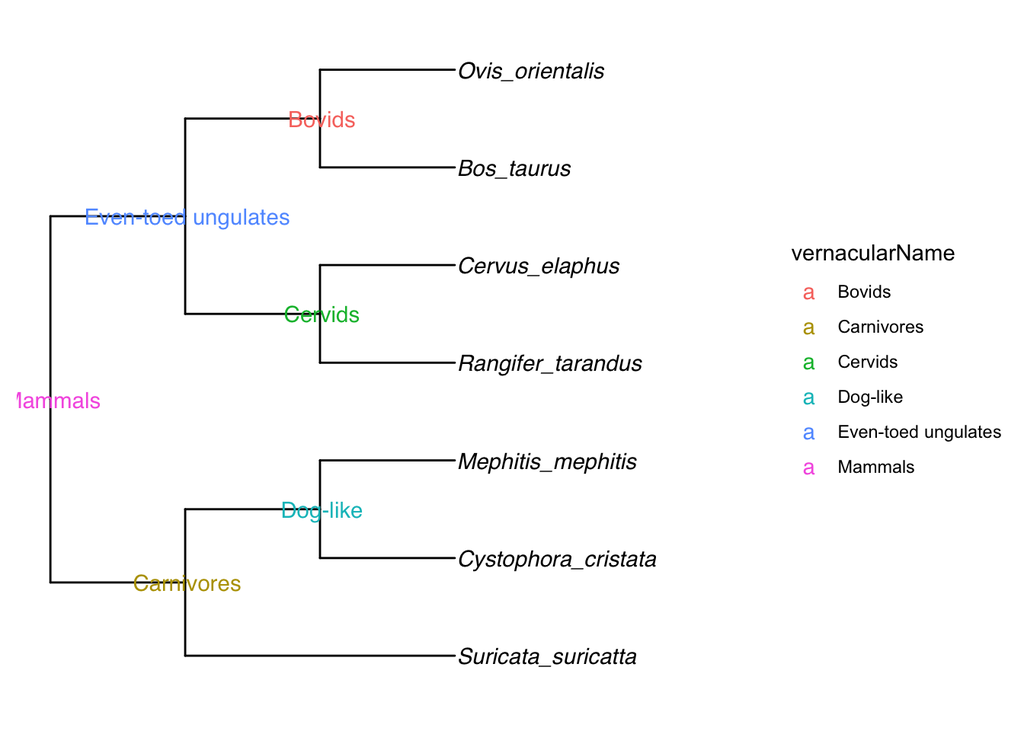

```r
ggtree(tree_data) +
  geom_tiplab(fontface = "italic") +
  xlim(0,5) +
  geom_nodelab(mapping = aes(label = vernacularName, color = vernacularName))
```

```r
library(dplyr)
species <- read.csv("../data-raw/species.csv")
surveys <- read.csv("../data-raw/surveys.csv")

taxonomy_means <- full_join(surveys, species) %>%
  filter(!is.na(weight) & !is.na(hindfoot_length)) %>%
  group_by(species_id) %>%
  summarise(mean_weight = mean(weight), mean(hindfoot_length))
portal_taxonomy <- read.csv("../data-raw/portal-species-taxonomy.csv")
colnames(portal_taxonomy)
```

```
##  [1] "label"             "species_id"        "genus"
##  [4] "species"           "taxa"              "ott_name"
##  [7] "approximate_match" "ott_id"            "is_synonym"
## [10] "flags"
```

```r
portal_taxonomy_means <- full_join(portal_taxonomy, taxonomy_means)
library(tidytree)
portal_tree <- read.tree(file = "../data-raw/portal-tree.tre")
portal_tree
```

```
##
## Phylogenetic tree with 43 tips and 42 internal nodes.
##
## Tip labels:
##   Sigmodon_ochrognathus, Sigmodon_hispidus, Sigmodon_fulviventer, Neotoma_albigula, Onychomys_torridus, Onychomys_leucogaster, ...
## Node labels:
##   Amniota, mrcaott42ott29157, mrcaott42ott10477, mrcaott42ott48903, mrcaott739ott15637, mrcaott39197ott1067867, ...
##
## Rooted; no branch lengths.
```

```r
colnames(portal_taxonomy_means)
```

```
##  [1] "label"                 "species_id"            "genus"
##  [4] "species"               "taxa"                  "ott_name"
##  [7] "approximate_match"     "ott_id"                "is_synonym"
## [10] "flags"                 "mean_weight"           "mean(hindfoot_length)"
```

```r
portal_joined <- tidytree:::left_join.phylo(portal_tree, portal_taxonomy_means)
```

Homework Add node labels to your two tree plots of Portal tree data with average weight and hindfoot length. Use the column “taxa” both as label and fill color. 1. Join portal_tree and the dataframe with average weights and hindfoot lengths, and taxa data. 2. Plot it 3. Add tip labels colored by taxa 4. Add node labels

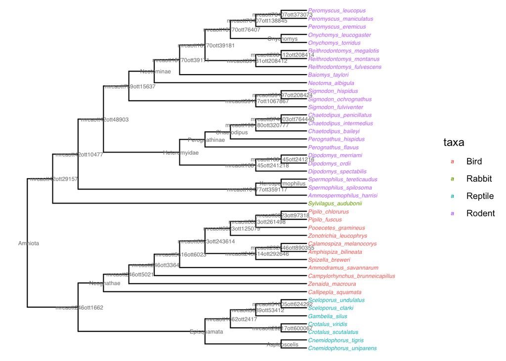

```r
ggtree(portal_joined) +
  geom_tiplab(mapping = aes(color = taxa), fontface = "italic", size = 2) +
  xlim(0,15) +
  geom_nodelab(mapping = aes(color = taxa), size =  2)
```